# R Graphics Showcase — from Statistical Basics to Showpiece Visualisations

# 10 Comparing categories and quantities efficiently

## 10.1 Cleveland dot plot

Dot plots use position rather than bar length and can be especially effective when values do not need a zero baseline.

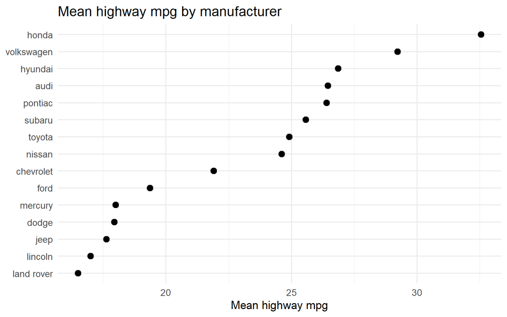

```r
manufacturer_mpg <- mpg |>
  group_by(manufacturer) |>
  summarise(mean_hwy = mean(hwy), .groups = "drop")

ggplot(
  manufacturer_mpg,
  aes(mean_hwy, fct_reorder(manufacturer, mean_hwy))
) +
  geom_point(size = 3) +
  labs(
    title = "Mean highway mpg by manufacturer",
    x = "Mean highway mpg",
    y = NULL
  )
```

## 10.2 Lollipop chart

A lollipop chart combines a point with a line to a baseline. It is visually lighter than a full bar chart but retains a strong positional cue.

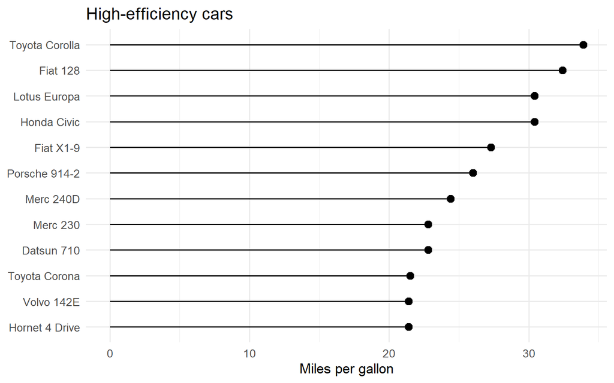

```r
car_top <- cars |>
  slice_max(mpg, n = 12)

ggplot(car_top, aes(mpg, fct_reorder(model, mpg))) +
  geom_segment(aes(x = 0, xend = mpg, yend = model)) +
  geom_point(size = 3) +
  labs(
    title = "High-efficiency cars",
    x = "Miles per gallon",
    y = NULL
  )
```

## 10.3 Dumbbell plot

A dumbbell plot highlights the difference between two measurements for each group. It is more direct than grouped bars when the within-group gap is the main quantity of interest.

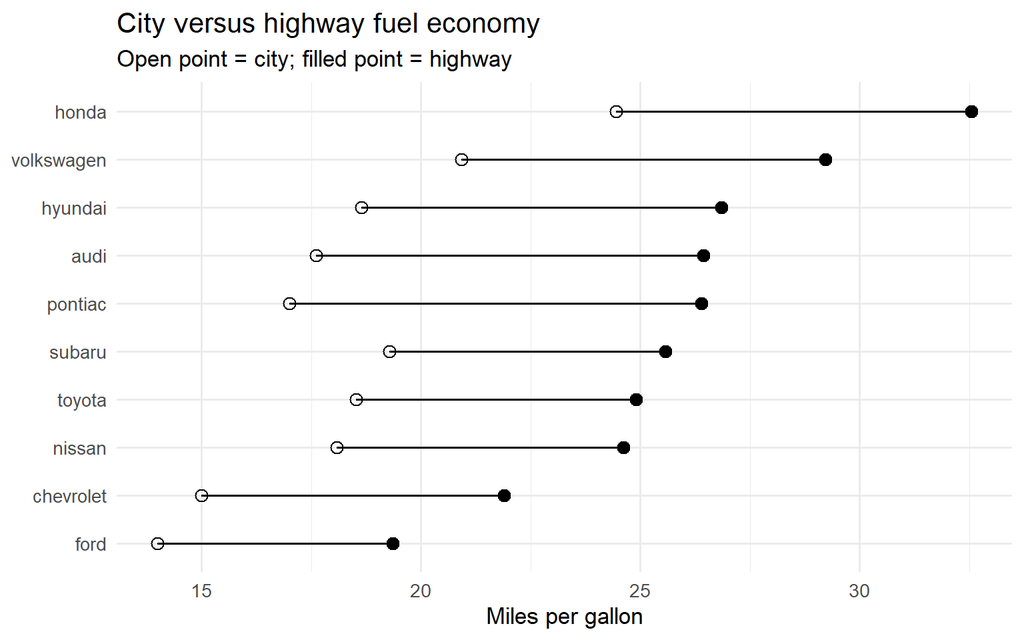

```r
comparison <- mpg |>
  group_by(manufacturer) |>
  summarise(
    city = mean(cty),
    highway = mean(hwy),
    .groups = "drop"
  ) |>
  slice_max(highway, n = 10) |>
  mutate(manufacturer = fct_reorder(manufacturer, highway))

ggplot(comparison, aes(y = manufacturer)) +
  geom_segment(
    aes(x = city, xend = highway, yend = manufacturer)
  ) +
  geom_point(aes(x = city), shape = 1, size = 3) +
  geom_point(aes(x = highway), size = 3) +
  labs(
    title = "City versus highway fuel economy",
    subtitle = "Open point = city; filled point = highway",
    x = "Miles per gallon",
    y = NULL
  )
```

## 10.4 Slope chart

Slope charts are ideal for “before versus after” comparisons. The direction and steepness of each line encode change.

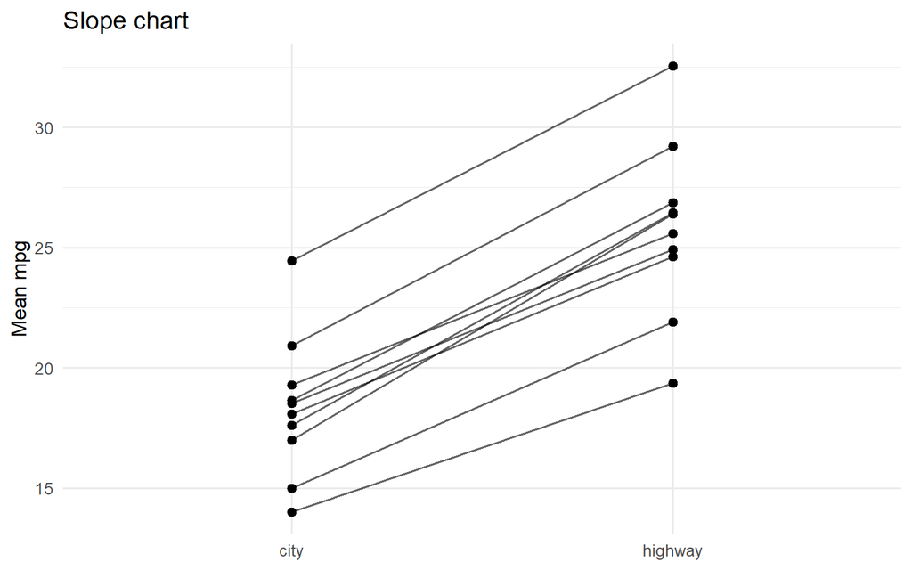

```r
slope_data <- comparison |>
  select(manufacturer, city, highway) |>
  pivot_longer(
    c(city, highway),
    names_to = "condition",
    values_to = "mpg"
  ) |>
  mutate(
    condition = factor(
      condition,
      levels = c("city", "highway")
    )
  )

ggplot(slope_data, aes(condition, mpg, group = manufacturer)) +
  geom_line(alpha = 0.6) +
  geom_point(size = 2.2) +
  labs(
    title = "Slope chart",
    x = NULL,
    y = "Mean mpg"
  )
```

# 11 Heatmaps and matrices

## 11.1 Count heatmap

Heatmaps encode a matrix through colour. They are compact and useful for pattern detection, but exact comparisons are difficult without labels.

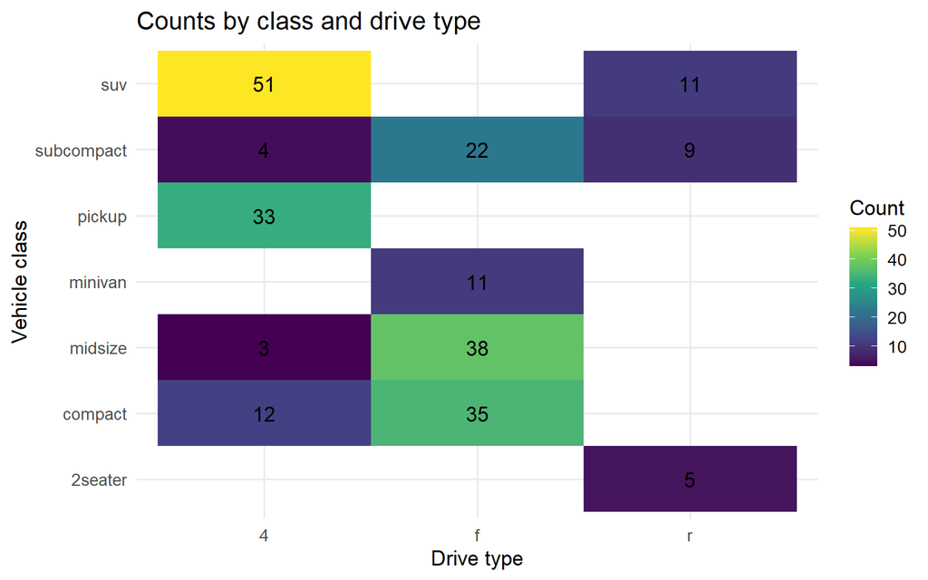

```r
heat <- mpg |>
  count(class, drv)

ggplot(heat, aes(drv, class, fill = n)) +
  geom_tile() +
  geom_text(aes(label = n)) +
  scale_fill_viridis_c() +
  labs(
    title = "Counts by class and drive type",
    x = "Drive type",
    y = "Vehicle class",
    fill = "Count"
  )
```

## 11.2 Correlation heatmap

A correlation matrix is naturally stored as a square matrix, whereas `ggplot2` works most naturally with one pair of variables per row. We therefore convert the matrix to long format before plotting.

The heatmap is useful for scanning broad correlation structure. The printed coefficients retain numerical precision.

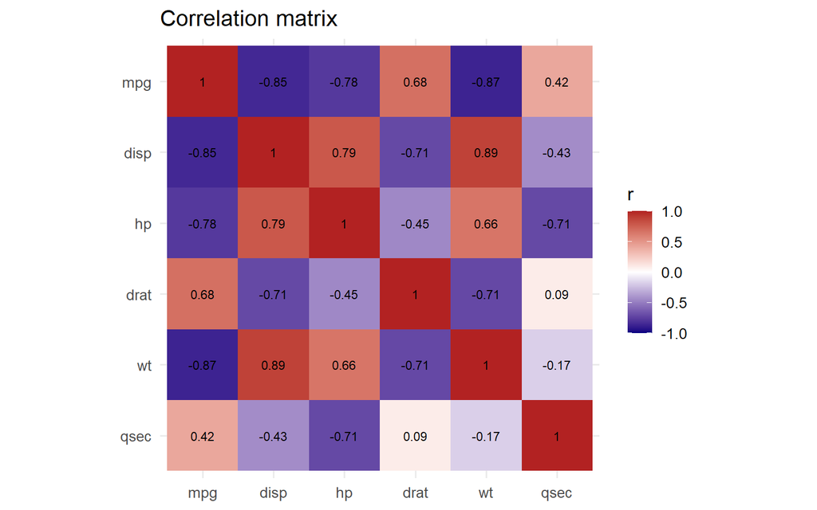

```r
vars <- c("mpg", "disp", "hp", "drat", "wt", "qsec")

cor_long <- cars |>
  select(all_of(vars)) |>
  cor() |>
  as.data.frame() |>
  rownames_to_column("var1") |>
  pivot_longer(
    cols = -var1,
    names_to = "var2",
    values_to = "correlation"
  ) |>
  mutate(
    var1 = factor(var1, levels = rev(vars)),
    var2 = factor(var2, levels = vars)
  )

ggplot(cor_long, aes(var2, var1, fill = correlation)) +
  geom_tile() +
  geom_text(
    aes(label = round(correlation, 2)),
    size = 3
  ) +
  scale_fill_gradient2(
    low = "navy",
    mid = "white",
    high = "firebrick",
    midpoint = 0,
    limits = c(-1, 1)
  ) +
  coord_equal() +
  labs(
    title = "Correlation matrix",
    x = NULL,
    y = NULL,
    fill = "r"
  )
```

# 12 Uncertainty and statistical estimates

## 12.1 Means with confidence intervals

An interval plot emphasizes an **estimate and its uncertainty** rather than the distribution of individual observations.

Confidence intervals for a mean should not be interpreted as ranges containing 95% of the observations.

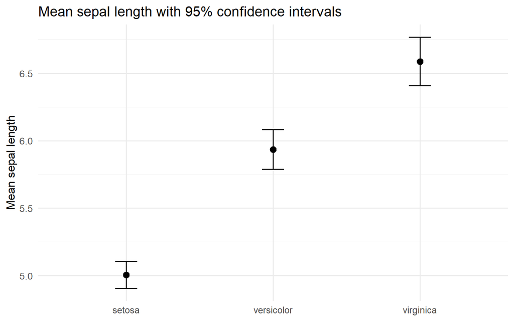

```r
iris_summary <- as_tibble(iris) |>
  group_by(Species) |>
  summarise(
    n = n(),
    mean = mean(Sepal.Length),
    se = sd(Sepal.Length) / sqrt(n),
    lower = mean - qt(0.975, n - 1) * se,
    upper = mean + qt(0.975, n - 1) * se,
    .groups = "drop"
  )

ggplot(iris_summary, aes(Species, mean)) +
  geom_point(size = 3) +
  geom_errorbar(
    aes(ymin = lower, ymax = upper),
    width = 0.15
  ) +
  labs(
    title = "Mean sepal length with 95% confidence intervals",
    x = NULL,
    y = "Mean sepal length"
  )
```

## 12.2 Forest / coefficient plot

A coefficient plot is a compact way to present several model estimates and their intervals. The vertical reference at zero makes sign and compatibility with a null effect easy to inspect.

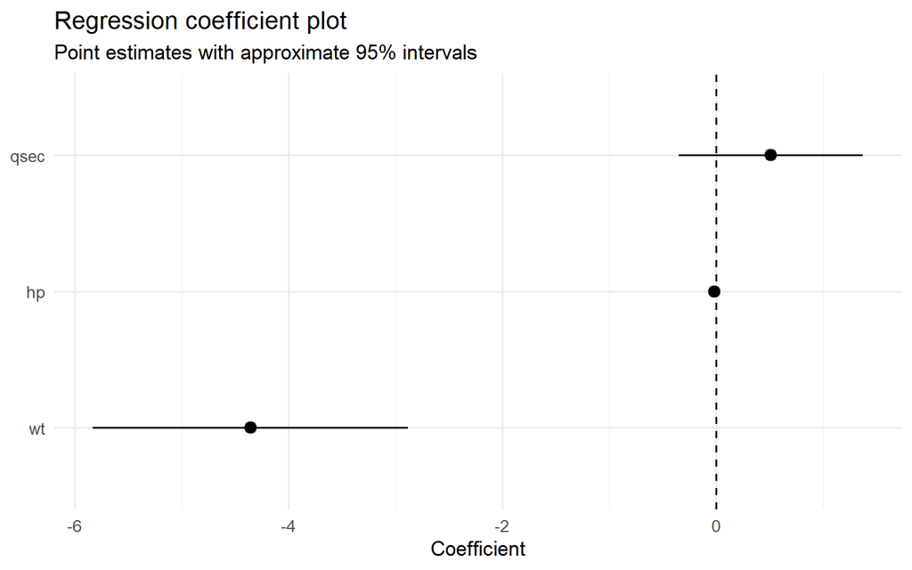

```r
fit <- lm(mpg ~ wt + hp + qsec, data = cars)

coef_table <- summary(fit)$coefficients |>
  as.data.frame() |>
  rownames_to_column("term") |>
  as_tibble() |>
  filter(term != "(Intercept)") |>
  transmute(
    term,
    estimate = Estimate,
    se = `Std. Error`,
    lower = estimate - 1.96 * se,
    upper = estimate + 1.96 * se
  )

ggplot(
  coef_table,
  aes(estimate, fct_reorder(term, estimate))
) +
  geom_vline(xintercept = 0, linetype = 2) +
  geom_pointrange(
    aes(xmin = lower, xmax = upper)
  ) +
  labs(
    title = "Regression coefficient plot",
    subtitle = "Point estimates with approximate 95% intervals",
    x = "Coefficient",
    y = NULL
  )
```

## 12.3 Funnel-style plot

Funnel plots visualize how sampling variability changes with precision or sample size. They are common in meta-analysis and quality monitoring.

This simulated example focuses on the geometry rather than a formal publication-bias analysis.

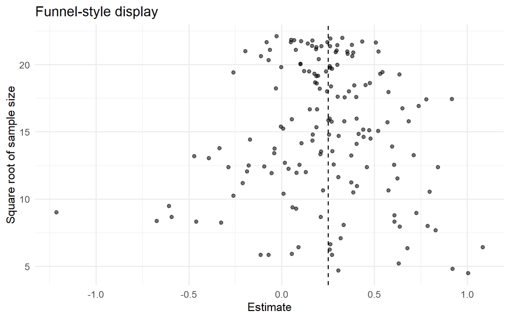

```r
set.seed(21)

funnel <- tibble(
  n = sample(20:500, 160, replace = TRUE),
  estimate = rnorm(
    160,
    mean = 0.25,
    sd = 1 / sqrt(n / 20)
  )
)

ggplot(funnel, aes(estimate, sqrt(n))) +
  geom_point(alpha = 0.55) +
  geom_vline(xintercept = 0.25, linetype = 2) +
  labs(
    title = "Funnel-style display",
    x = "Estimate",
    y = "Square root of sample size"
  )
```

# 13 Model diagnostics

## 13.1 Q-Q plot

A Q-Q plot compares empirical quantiles with theoretical normal quantiles. Systematic curvature is more informative than small random deviations.

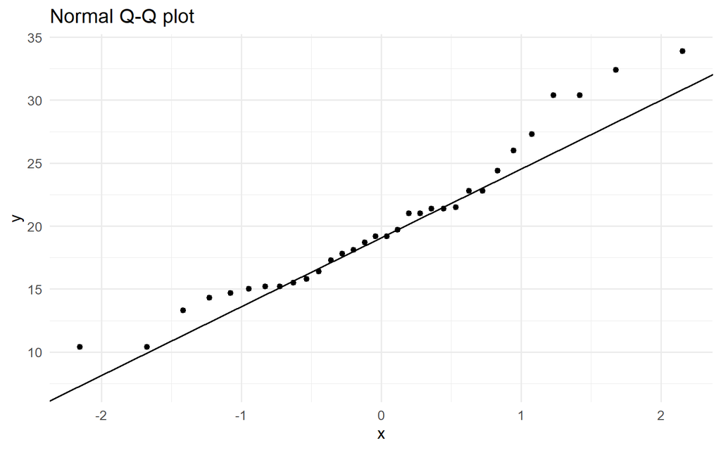

```r
ggplot(cars, aes(sample = mpg)) +
  stat_qq() +
  stat_qq_line() +
  labs(title = "Normal Q-Q plot")
```

## 13.2 Residuals versus fitted values

This diagnostic helps detect nonlinearity, changing residual variance and unusual observations.

A smooth trend should ideally remain close to zero if the mean structure is adequately represented.

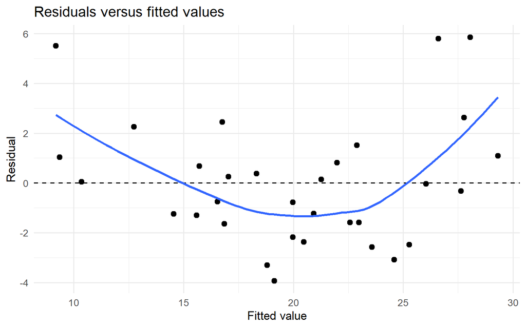

```r
fit2 <- lm(mpg ~ wt + hp, data = cars)

diag <- tibble(
  fitted = fitted(fit2),
  residual = residuals(fit2)
)

ggplot(diag, aes(fitted, residual)) +
  geom_hline(yintercept = 0, linetype = 2) +
  geom_point(size = 2.5) +
  geom_smooth(se = FALSE) +
  labs(
    title = "Residuals versus fitted values",
    x = "Fitted value",
    y = "Residual"
  )
```

## 13.3 Bland-Altman-style agreement plot

Two measurement methods can be highly correlated while disagreeing systematically. A Bland-Altman plot focuses directly on **differences between methods**.

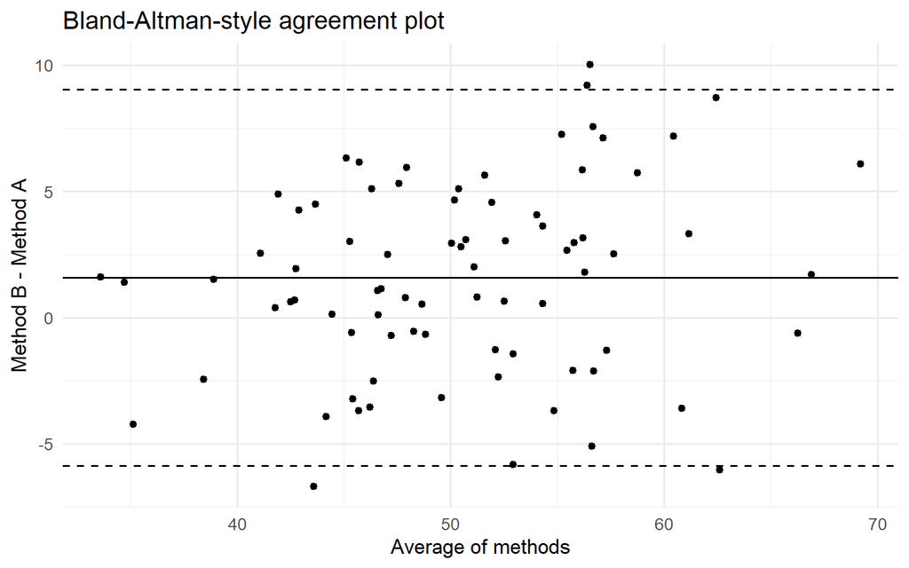

```r
set.seed(12)

methods <- tibble(
  method_a = rnorm(80, 50, 8),
  method_b = method_a + rnorm(80, 1.5, 4)
) |>
  mutate(
    average = (method_a + method_b) / 2,
    difference = method_b - method_a
  )

md <- mean(methods$difference)
sd_d <- sd(methods$difference)

ggplot(methods, aes(average, difference)) +
  geom_point() +
  geom_hline(yintercept = md) +
  geom_hline(
    yintercept = md + 1.96 * sd_d,
    linetype = 2
  ) +
  geom_hline(
    yintercept = md - 1.96 * sd_d,
    linetype = 2
  ) +
  labs(
    title = "Bland-Altman-style agreement plot",
    x = "Average of methods",
    y = "Method B - Method A"
  )
```

# 14 Repeated measurements and trajectories

## 14.1 Spaghetti plot

A spaghetti plot draws one trajectory per observational unit. It preserves individual heterogeneity that a mean trajectory would hide.

The limitation is visual clutter: with hundreds of subjects, sampling or partial transparency is usually necessary.

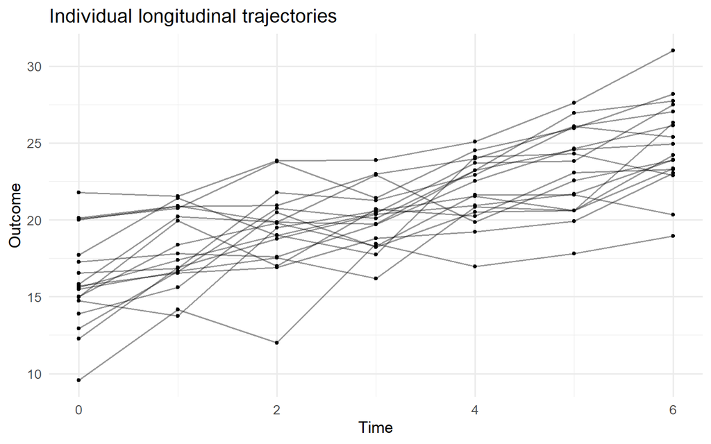

```r
set.seed(4)

longitudinal <- crossing(
  id = factor(1:18),
  time = 0:6
) |>
  mutate(
    random_intercept = rep(rnorm(18, 0, 3), each = 7),
    outcome =
      15 + 1.4 * time +
      random_intercept +
      rnorm(n(), 0, 1.5)
  )

ggplot(longitudinal, aes(time, outcome, group = id)) +
  geom_line(alpha = 0.4) +
  geom_point(size = 1) +
  labs(
    title = "Individual longitudinal trajectories",
    x = "Time",
    y = "Outcome"
  )
```

## 14.2 Mean trajectory with uncertainty ribbon

A ribbon displays a continuous interval around a curve. It is efficient for uncertainty that changes over time.

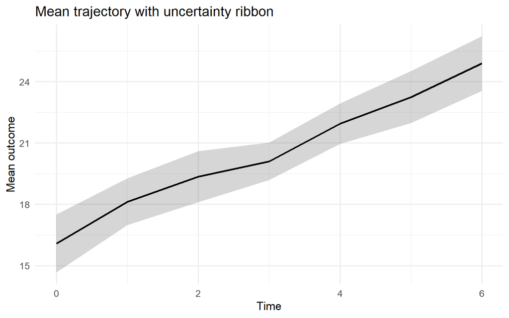

```r
ribbon_data <- longitudinal |>
  group_by(time) |>
  summarise(
    mean = mean(outcome),
    se = sd(outcome) / sqrt(n()),
    lower = mean - 1.96 * se,
    upper = mean + 1.96 * se,
    .groups = "drop"
  )

ggplot(ribbon_data, aes(time, mean)) +
  geom_ribbon(
    aes(ymin = lower, ymax = upper),
    alpha = 0.2
  ) +
  geom_line(linewidth = 1) +
  labs(
    title = "Mean trajectory with uncertainty ribbon",
    x = "Time",
    y = "Mean outcome"
  )
```

# 15 Multivariate data

## 15.1 Scatterplot matrix

A scatterplot matrix displays all pairwise relationships among several variables. It is useful during exploratory analysis but becomes visually expensive as the number of variables grows.

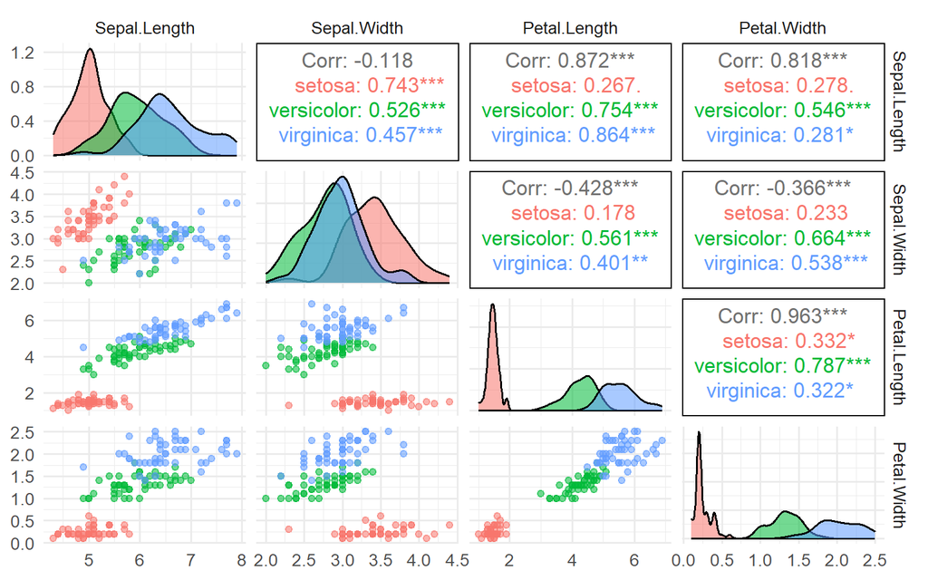

```r
if (has_pkg("GGally")) {
  GGally::ggpairs(
    iris,
    columns = 1:4,
    aes(colour = Species, alpha = 0.6)
  )
}
```

## 15.2 PCA score plot

Principal component analysis rotates a multivariate dataset into directions of decreasing variance. A score plot displays observations in the new coordinate system.

Interpretation should consider how much variance the shown components explain and what loadings define those components.

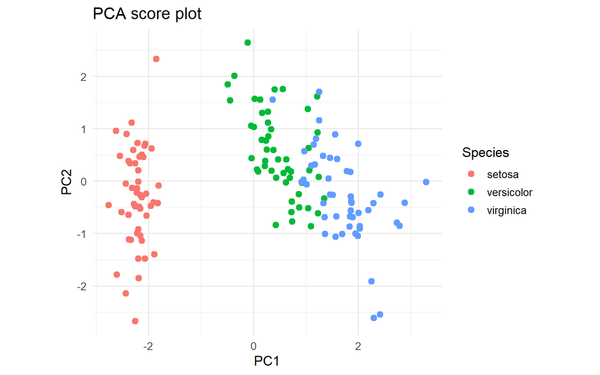

```r
pca <- prcomp(
  iris |>
    select(where(is.numeric)),
  scale. = TRUE
)

pca_scores <- as_tibble(pca$x[, 1:2]) |>
  mutate(Species = iris$Species)

ggplot(pca_scores, aes(PC1, PC2, colour = Species)) +
  geom_point(size = 2.5) +
  coord_equal() +
  labs(title = "PCA score plot")
```

## 15.3 Convex hulls

Convex hulls outline the smallest convex region containing each group. They are descriptive envelopes, **not confidence regions**.

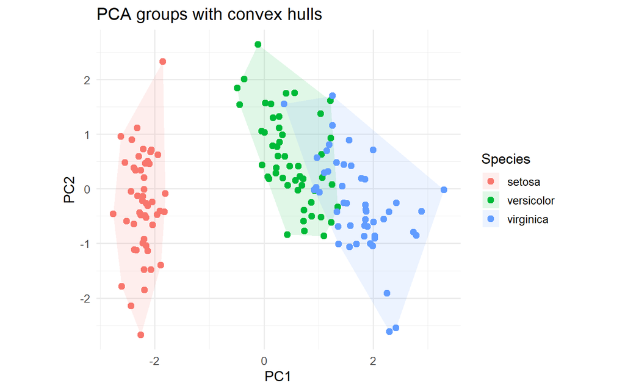

```r
hulls <- pca_scores |>
  group_by(Species) |>
  slice(chull(PC1, PC2)) |>
  ungroup()

ggplot(pca_scores, aes(PC1, PC2, colour = Species)) +
  geom_polygon(
    data = hulls,
    aes(fill = Species, group = Species),
    alpha = 0.12,
    colour = NA
  ) +
  geom_point(size = 2.5) +
  coord_equal() +
  labs(title = "PCA groups with convex hulls")
```

## 15.4 Parallel-coordinate-style display

Parallel coordinates represent each observation as a line crossing several variable axes. Standardisation is essential when variables use different units.

This display is useful for identifying profile shapes, but individual line tracing becomes difficult with many observations.

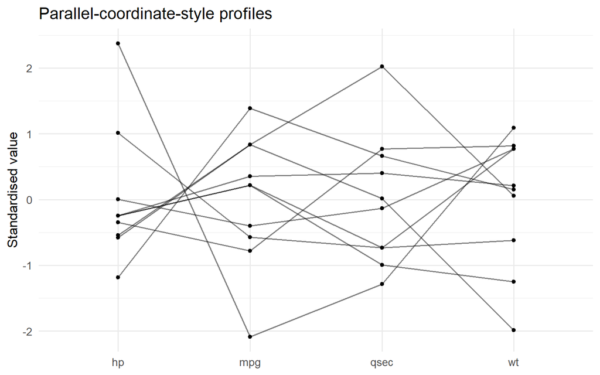

```r
parallel_data <- cars |>
  slice_head(n = 10) |>
  select(model, mpg, wt, hp, qsec) |>
  mutate(
    across(-model, ~ as.numeric(scale(.x)))
  ) |>
  pivot_longer(
    -model,
    names_to = "variable",
    values_to = "z"
  )

ggplot(parallel_data, aes(variable, z, group = model)) +
  geom_line(alpha = 0.5) +
  geom_point(size = 1.3) +
  labs(
    title = "Parallel-coordinate-style profiles",
    x = NULL,
    y = "Standardised value"
  )
```

# 16 Radar / spider plot

Radar charts represent a multivariate profile around radial axes. They can be visually memorable and useful when the focus is the **shape of a profile across a small number of variables**.

They are less suitable for precise comparisons because values are read using distance and polygon shape rather than aligned Cartesian position. Always standardise variables before comparing quantities measured on different scales.

Here each polygon represents the average profile of cars with 4, 6 or 8 cylinders.

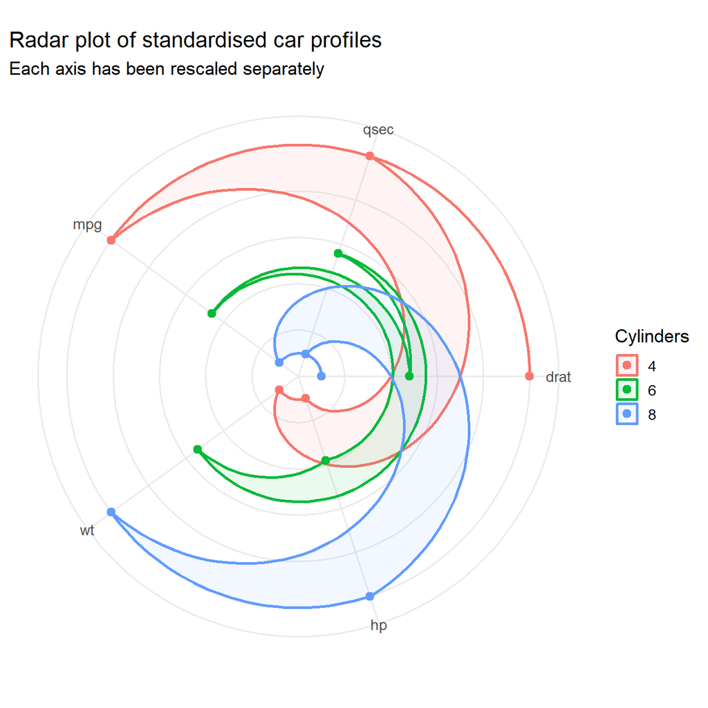

```r
radar_data <- cars |>
  group_by(cyl) |>
  summarise(
    mpg = mean(mpg),
    hp = mean(hp),
    wt = mean(wt),
    qsec = mean(qsec),
    drat = mean(drat),
    .groups = "drop"
  ) |>
  pivot_longer(
    -cyl,
    names_to = "metric",
    values_to = "value"
  ) |>
  group_by(metric) |>
  mutate(score = rescale(value, to = c(0.1, 1))) |>
  ungroup() |>
  mutate(
    metric = factor(
      metric,
      levels = c("mpg", "qsec", "drat", "hp", "wt")
    )
  )

ggplot(
  radar_data,
  aes(metric, score, group = cyl, colour = cyl, fill = cyl)
) +
  geom_polygon(alpha = 0.08, linewidth = 1) +
  geom_point(size = 2.5) +
  coord_polar(start = -pi / 2) +
  scale_y_continuous(
    limits = c(0, 1),
    breaks = seq(0.2, 1, 0.2),
    labels = NULL
  ) +
  labs(
    title = "Radar plot of standardised car profiles",
    subtitle = "Each axis has been rescaled separately",
    x = NULL,
    y = NULL,
    colour = "Cylinders",
    fill = "Cylinders"
  ) +
  theme(
    panel.grid.minor = element_blank(),
    axis.text.y = element_blank()
  )
```

# 17 Circular and polar graphics

Circular layouts can display composition or repeated categorical structures in a compact form. They are visually attractive but less precise than aligned Cartesian displays.

Use them when the circular organization has communicative value, not simply because it looks unusual.

## 17.1 Polar stacked bar / radial composition chart

This chart is similar in spirit to the radial example supplied with the course material: each cell type occupies an angular sector and phases are stacked radially.

```r
flow_data <- tribble(
  ~CellType,          ~Phase, ~n,
  "Ductal",           "G1",   160,
  "Ductal",           "S",     65,
  "Ductal",           "G2M",   28,
  "Ngn3-high-EP",     "G1",   110,
  "Ngn3-high-EP",     "S",     42,
  "Ngn3-high-EP",     "G2M",   20,
  "Endocrine",        "G1",   250,
  "Endocrine",        "S",     55,
  "Endocrine",        "G2M",   75,
  "Ngn3-low-EP",      "G1",    42,
  "Ngn3-low-EP",      "S",     15,
  "Ngn3-low-EP",      "G2M",   12,
  "Pre-endocrine",    "G1",    90,
  "Pre-endocrine",    "S",     28,
  "Pre-endocrine",    "G2M",   18
)
```

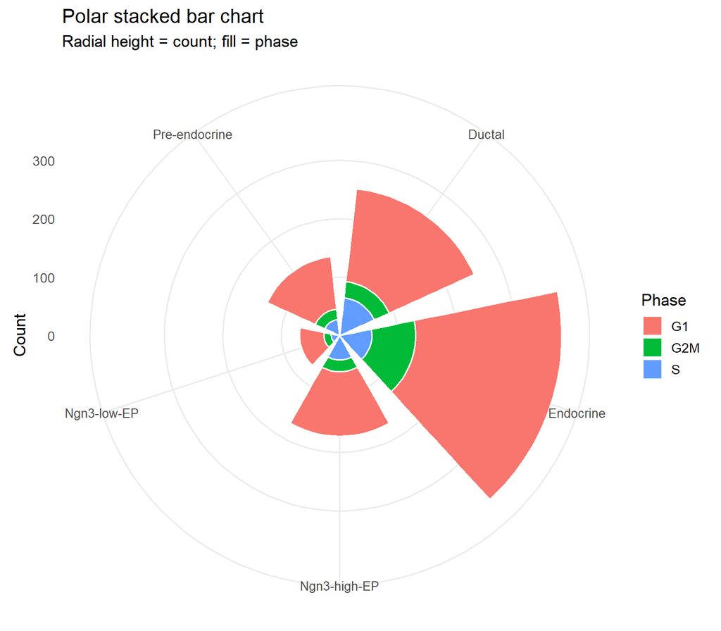

```r
ggplot(
  flow_data,
  aes(CellType, n, fill = Phase)
) +
  geom_col(width = 0.82, colour = "white") +
  coord_polar(start = 0) +
  labs(
    title = "Polar stacked bar chart",
    subtitle = "Radial height = count; fill = phase",
    x = NULL,
    y = "Count",
    fill = "Phase"
  ) +
  theme(
    axis.text.x = element_text(size = 10),
    panel.grid.minor = element_blank()
  )
```

A conventional lollipop chart can be transformed with polar coordinates. The result emphasizes ranking and creates a compact radial layout.

Again, use the ordinary Cartesian version when accurate comparison is more important than display impact.

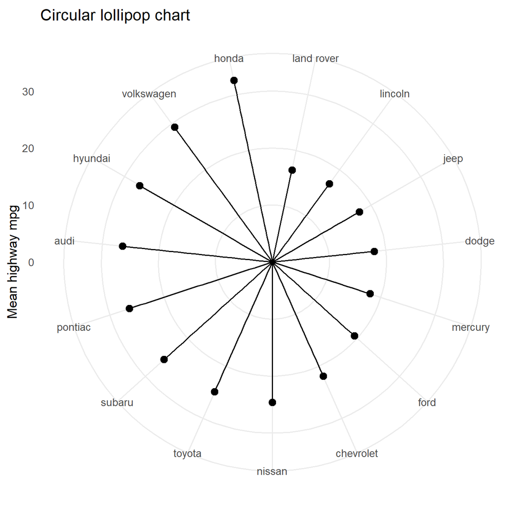

```r
circular_manufacturer <- manufacturer_mpg |>
  arrange(mean_hwy) |>
  mutate(
    manufacturer = factor(
      manufacturer,
      levels = manufacturer
    )
  )

ggplot(
  circular_manufacturer,
  aes(manufacturer, mean_hwy)
) +
  geom_segment(
    aes(
      xend = manufacturer,
      y = 0,
      yend = mean_hwy
    )
  ) +
  geom_point(size = 3) +
  coord_polar() +
  labs(
    title = "Circular lollipop chart",
    x = NULL,
    y = "Mean highway mpg"
  )
```

# 18 Flows between categories: alluvial / Sankey plot

An alluvial plot represents movement or composition between categorical stages. Ribbon width encodes quantity.

These plots are powerful when the central question is **where units flow from and to**. They become difficult to read with many stages, many categories or many thin ribbons.

The example below uses the same synthetic cell-type/phase table as the polar chart, allowing the two representations to be compared directly.

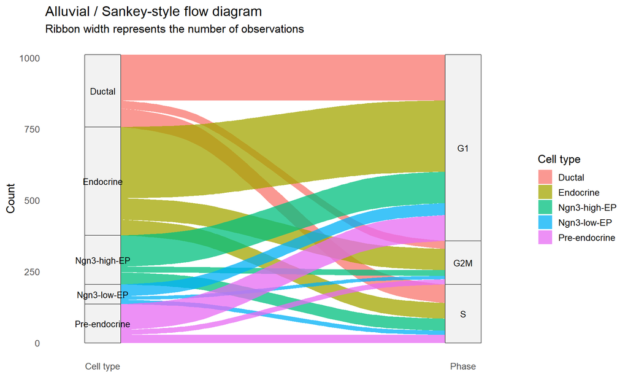

```r
if (has_pkg("ggalluvial")) {
  ggplot(
    flow_data,
    aes(
      axis1 = CellType,
      axis2 = Phase,
      y = n
    )
  ) +
    ggalluvial::geom_alluvium(
      aes(fill = CellType),
      width = 1 / 10,
      alpha = 0.75
    ) +
    ggalluvial::geom_stratum(
      width = 1 / 10,
      fill = "grey95",
      colour = "grey35"
    ) +
    ggalluvial::stat_stratum(
      geom = "text",
      aes(label = after_stat(stratum)),
      size = 3.6
    ) +
    scale_x_discrete(
      limits = c("Cell type", "Phase"),
      expand = c(0.08, 0.08)
    ) +
    labs(
      title = "Alluvial / Sankey-style flow diagram",
      subtitle = "Ribbon width represents the number of observations",
      x = NULL,
      y = "Count",
      fill = "Cell type"
    ) +
    theme(
      panel.grid = element_blank()
    )
}
```

# 19 Chord diagram

A chord diagram places categories around a circle and connects them with ribbons. It is a compact representation of a many-to-many relationship and is especially effective for symmetric networks or flow matrices.

The cost of the circular layout is reduced precision: exact ribbon widths are harder to compare than aligned bars. Chord diagrams are therefore best for **revealing dominant connections and network structure**, not for reading exact values.

```r
if (has_pkg("circlize")) {
  flow_matrix <- xtabs(
    n ~ CellType + Phase,
    data = flow_data
  )

  circlize::circos.clear()

  circlize::chordDiagram(
    flow_matrix,
    transparency = 0.25
  )

  title("Chord diagram: cell type and phase")

  circlize::circos.clear()
}
```

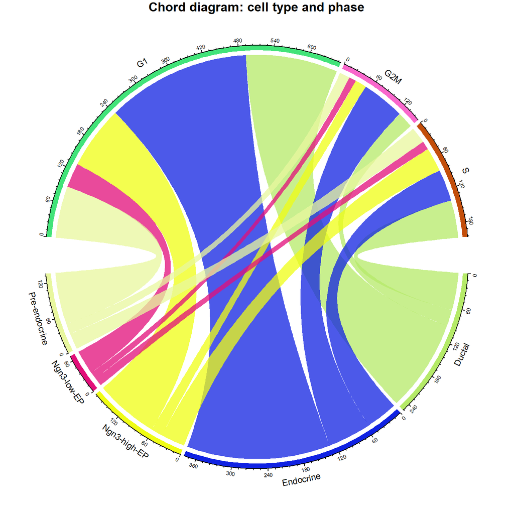

# 20 Hierarchical displays

## 20.1 Treemap

A treemap uses nested rectangles to represent part-to-whole structure. Rectangle area encodes magnitude and colour can encode another variable.

Treemaps are space-efficient, but comparing similarly sized rectangles is less accurate than comparing bar lengths.

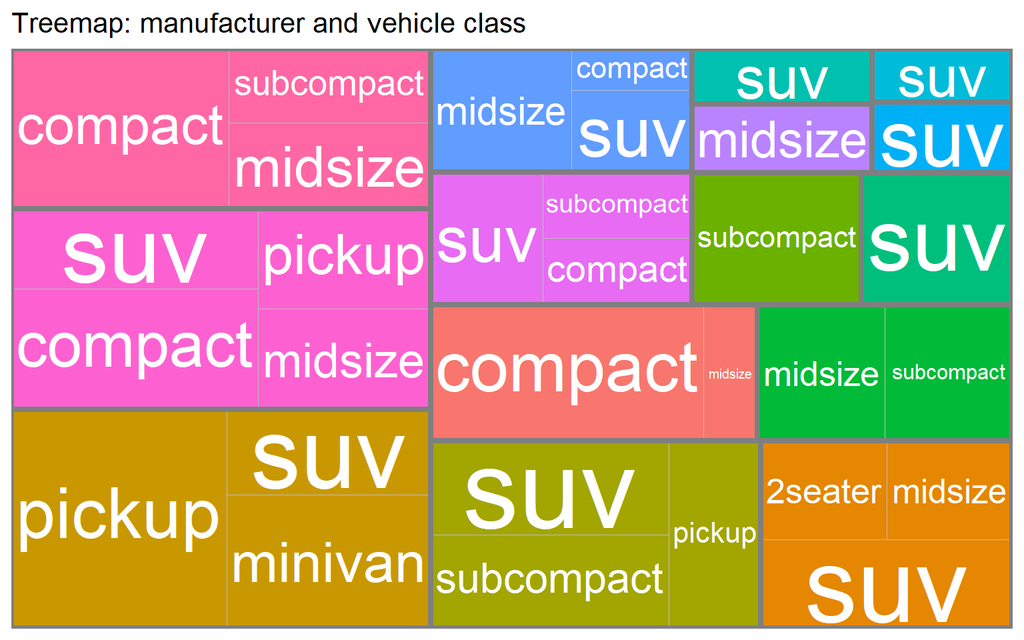

```r
if (has_pkg("treemapify")) {
  tree_data <- mpg |>
    count(manufacturer, class) |>
    group_by(manufacturer) |>
    mutate(total = sum(n)) |>
    ungroup()

  ggplot(
    tree_data,
    aes(
      area = n,
      fill = manufacturer,
      label = class,
      subgroup = manufacturer
    )
  ) +
    treemapify::geom_treemap() +
    treemapify::geom_treemap_subgroup_border() +
    treemapify::geom_treemap_text(
      colour = "white",
      place = "centre",
      grow = TRUE,
      reflow = TRUE
    ) +
    guides(fill = "none") +
    labs(
      title = "Treemap: manufacturer and vehicle class"
    )
}
```

## 20.2 Dendrogram

A dendrogram visualizes the nested structure produced by hierarchical clustering. The heights at which branches merge represent dissimilarity under the chosen clustering method.

Do not interpret a clustering tree without considering the distance measure, variable scaling and linkage method that created it.

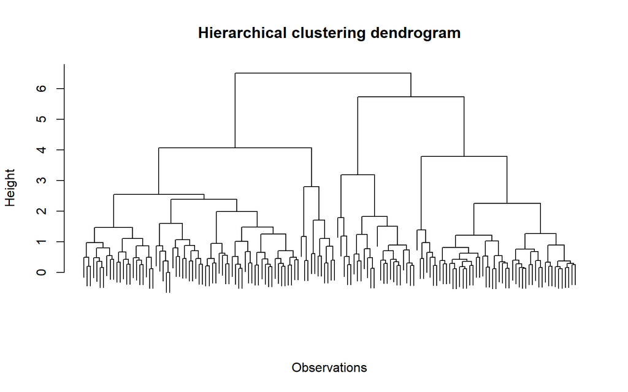

```r
iris_scaled <- scale(
  iris |>
    select(where(is.numeric))
)

hc <- hclust(dist(iris_scaled))

plot(
  hc,
  labels = FALSE,
  main = "Hierarchical clustering dendrogram",
  xlab = "Observations",
  sub = ""
)
```

# 21 Network-style visualisation

Networks represent entities as nodes and relationships as edges. They are appropriate when connections themselves are the data.

Network graphics can become unreadable quickly. Filtering, aggregation and meaningful layout choices are usually more important than decorative styling.

The following small example uses only base `ggplot2` geometry to avoid making a graph package mandatory.

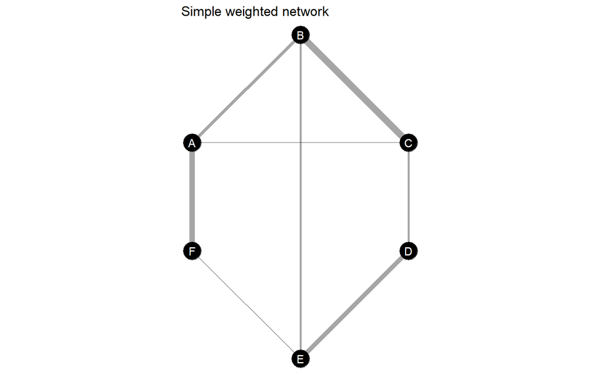

```r
nodes <- tibble(
  node = c("A", "B", "C", "D", "E", "F"),
  x = c(0, 1, 2, 2, 1, 0),
  y = c(1, 2, 1, 0, -1, 0)
)

edges <- tribble(
  ~from, ~to, ~weight,
  "A", "B", 4,
  "B", "C", 7,
  "C", "D", 3,
  "D", "E", 5,
  "E", "F", 2,
  "F", "A", 6,
  "A", "C", 2,
  "B", "E", 3
) |>
  left_join(
    nodes |> rename(from = node, x_from = x, y_from = y),
    by = "from"
  ) |>
  left_join(
    nodes |> rename(to = node, x_to = x, y_to = y),
    by = "to"
  )

ggplot() +
  geom_segment(
    data = edges,
    aes(
      x = x_from,
      y = y_from,
      xend = x_to,
      yend = y_to,
      linewidth = weight
    ),
    alpha = 0.35
  ) +
  geom_point(
    data = nodes,
    aes(x, y),
    size = 8
  ) +
  geom_text(
    data = nodes,
    aes(x, y, label = node),
    colour = "white"
  ) +
  scale_linewidth(range = c(0.5, 3)) +
  coord_equal() +
  guides(linewidth = "none") +
  labs(title = "Simple weighted network") +
  theme_void()
```

# 22 Polar composition versus Cartesian composition

The same data can be drawn as conventional stacked bars or in polar coordinates. Comparing them side by side is a useful perceptual exercise.

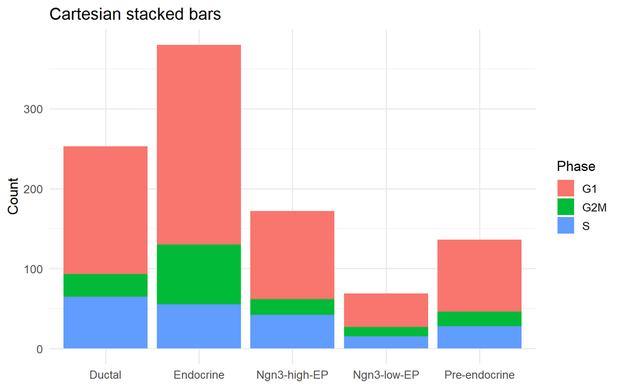

```r
ggplot(flow_data, aes(CellType, n, fill = Phase)) +
  geom_col() +
  labs(
    title = "Cartesian stacked bars",
    x = NULL,
    y = "Count"
  )
```

The Cartesian version makes aligned lengths easier to compare; the polar version emphasizes overall profile and provides more visual impact.

# 23 Logarithmic scales

Log scales are useful for positive variables spanning orders of magnitude and for multiplicative relationships.

A transformed scale changes the visual meaning of distance, so the transformation should always be stated explicitly.

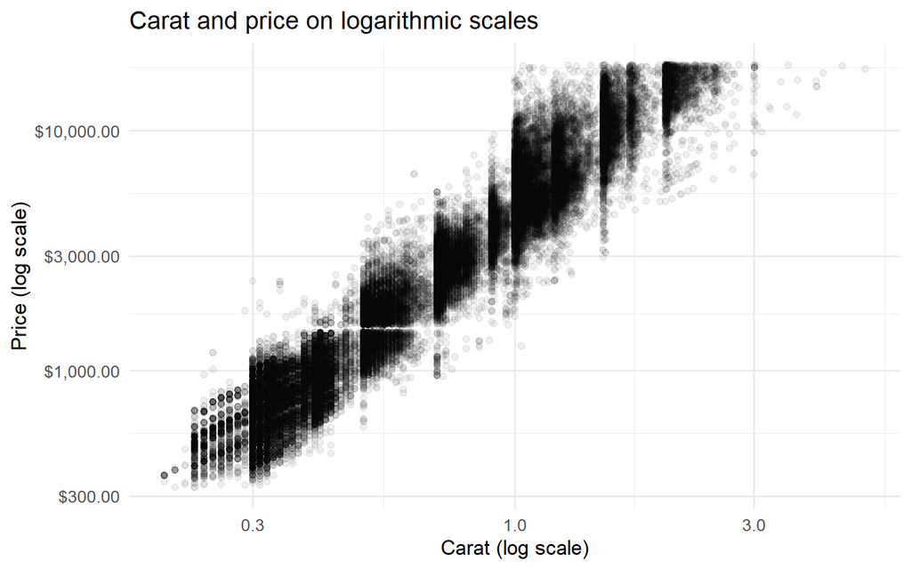

```r
ggplot(diamonds, aes(carat, price)) +
  geom_point(alpha = 0.06) +
  scale_x_log10() +
  scale_y_log10(labels = label_dollar()) +
  labs(
    title = "Carat and price on logarithmic scales",
    x = "Carat (log scale)",
    y = "Price (log scale)"
  )
```

# 24 Annotation and visual hierarchy

Annotations guide attention and explain why a feature matters. Good annotation is selective: labelling every observation usually creates noise.

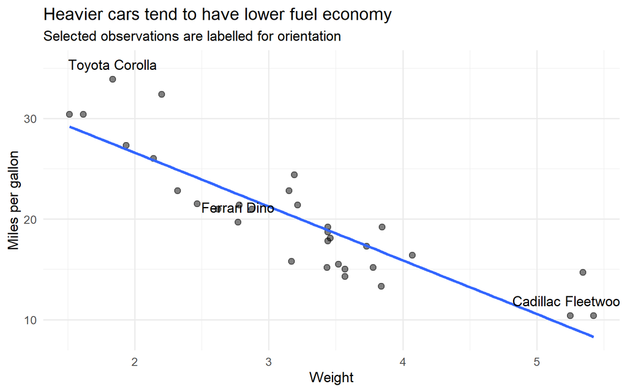

```r
labeled <- cars |>
  filter(
    model %in% c(
      "Toyota Corolla",
      "Cadillac Fleetwood",
      "Ferrari Dino"
    )
  )

ggplot(cars, aes(wt, mpg)) +
  geom_point(alpha = 0.5, size = 2.5) +
  geom_smooth(method = "lm", se = FALSE) +
  geom_text(
    data = labeled,
    aes(label = model),
    nudge_y = 1.5,
    check_overlap = TRUE
  ) +
  labs(
    title = "Heavier cars tend to have lower fuel economy",
    subtitle = "Selected observations are labelled for orientation",
    x = "Weight",
    y = "Miles per gallon"
  )
```

# 25 Misleading graphics and scale choices

Visual design can exaggerate differences even when the underlying numbers are correct.

Bars encode magnitude through length from a baseline; truncating that baseline can therefore distort the perceived ratio of values.

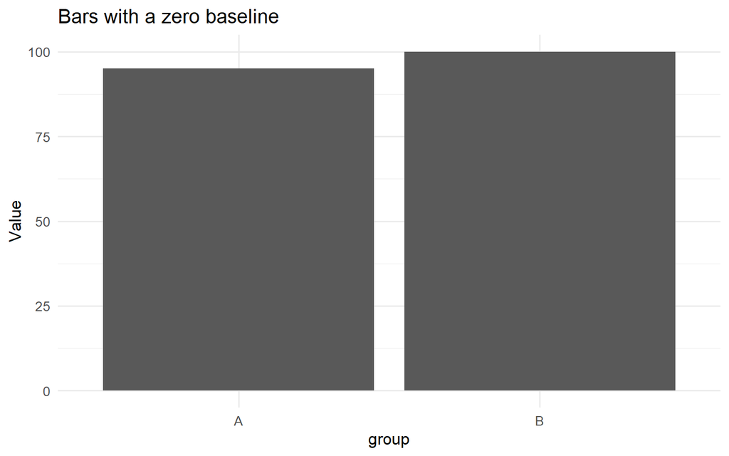

```r
axis_example <- tibble(
  group = c("A", "B"),
  value = c(95, 100)
)

ggplot(axis_example, aes(group, value)) +
  geom_col() +
  labs(
    title = "Bars with a zero baseline",
    y = "Value"
  )
```

When points rather than bars are used, a non-zero axis can be entirely appropriate if the relevant task is comparison of position rather than length.

# 26 Spatial visualisation

Maps are powerful because geographic position already carries meaning. They also introduce distinctive statistical risks:

- raw counts can be misleading when regions differ in population or area;
- apparent spatial patterns can depend on classification boundaries;
- choropleths encourage ecological interpretation at the region level;
- projection affects shape, area and distance.

## 26.1 US state choropleth

This example uses built-in state population values and polygon data from the optional `maps` package.

```r
if (has_pkg("maps")) {
  state_map <- map_data("state")

  state_pop <- as_tibble(state.x77, rownames = "region") |>
    transmute(
      region = str_to_lower(region),
      population = Population
    )

  state_map2 <- state_map |>
    left_join(state_pop, by = "region")

  ggplot(
    state_map2,
    aes(long, lat, group = group, fill = population)
  ) +
    geom_polygon(colour = "white", linewidth = 0.15) +
    coord_quickmap() +
    scale_fill_viridis_c() +
    labs(
      title = "US state population choropleth",
      fill = "Population\n(thousands)"
    ) +
    theme_void()
}
```

[output not shown]

# 27 Interactive graphics

Interactivity can support exploration through zooming, tooltips, filtering and linked views. It should reveal information rather than merely add controls.

A useful principle is:

> Interaction should answer a question that the static graphic cannot answer efficiently.

```r
if (has_pkg("plotly")) {
  p_interactive <- ggplot(
    mpg,
    aes(
      displ,
      hwy,
      colour = class,
      text = paste(
        "Manufacturer:", manufacturer,
        "<br>Model:", model,
        "<br>Highway mpg:", hwy
      )
    )
  ) +
    geom_point(size = 2.5) +
    labs(
      title = "Interactive scatter plot",
      x = "Engine displacement",
      y = "Highway mpg"
    )

  plotly::ggplotly(
    p_interactive,
    tooltip = "text"
  )
}
```

[interactive chart not shown]

# 28 Interactive graphics with Shiny

Shiny adds reactive inputs to the visualization process. The user no longer receives a fixed view: they define part of the statistical query.

A good Shiny app exposes meaningful choices, such as a variable, subgroup, threshold or smoothing parameter. A poor app simply adds many controls because they are available.

```r
library(shiny)

ui <- fluidPage(
  titlePanel("Explore diamond prices"),
  sidebarLayout(
    sidebarPanel(
      sliderInput(
        "binwidth",
        "Histogram bin width",
        min = 100,
        max = 2000,
        value = 500,
        step = 100
      )
    ),
    mainPanel(
      plotOutput("hist")
    )
  )
)

server <- function(input, output, session) {
  output$hist <- renderPlot({
    ggplot(diamonds, aes(price)) +
      geom_histogram(
        binwidth = input$binwidth
      )
  })
}

shinyApp(ui, server)
```

# 29 Reproducible graphics

A reproducible graphic records the complete route from data to image. This makes it possible to update, audit and version the visualization.

Avoid workflows in which labels, colours or values are changed manually after export without leaving a record in the analysis code.

## 29.1 A reusable plotting function

Functions are useful when the same statistical display is needed repeatedly.

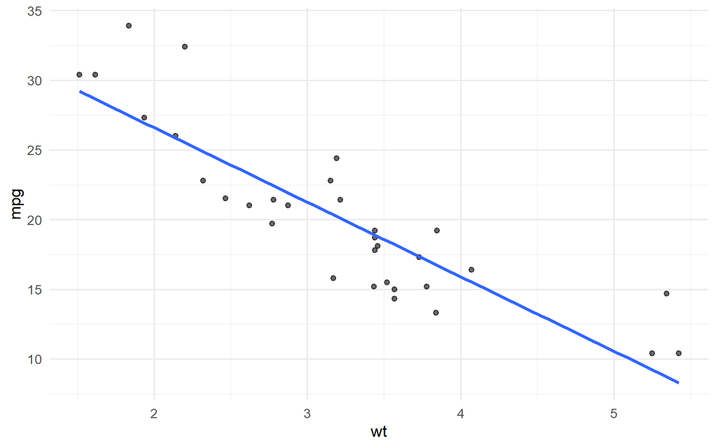

```r
scatter_with_lm <- function(data, x, y) {
  ggplot(
    data,
    aes(x = {{ x }}, y = {{ y }})
  ) +
    geom_point(alpha = 0.6) +
    geom_smooth(method = "lm", se = FALSE) +
    labs(
      x = rlang::as_label(enquo(x)),
      y = rlang::as_label(enquo(y))
    )
}

scatter_with_lm(cars, wt, mpg)
```

## 29.2 Saving a figure

`ggsave()` records dimensions and resolution explicitly.

```r
p <- ggplot(cars, aes(wt, mpg)) +
  geom_point() +
  geom_smooth(method = "lm", se = FALSE)

ggsave(
  filename = "weight_mpg.png",
  plot = p,
  width = 7,
  height = 5,
  dpi = 300
)
```

# 30 A compact decision guide

| Statistical question | Strong first choice | Useful alternatives |
| --- | --- | --- |
| How frequent are categories? | Bar chart | Ordered dot plot, proportional bars |
| How are two categorical variables related? | Proportional bars | Mosaic plot, heatmap |
| What is the distribution of one variable? | Histogram | Density, ECDF |
| How do distributions differ by group? | Boxplot + points | Violin, raincloud, ridgeline |
| Are two quantitative variables associated? | Scatter plot | Smoother, 2D bins, contours |
| Is overplotting severe? | Transparency | Hexbin, 2D binning |
| How does a quantity change over time? | Line chart | Ribbon, step chart |
| How do ranks change over time? | Bump chart | Slope chart |
| How do two measurements differ by group? | Dumbbell | Slope chart |
| How uncertain are estimates? | Interval / forest plot | Ribbon, density-based interval |
| Are model assumptions plausible? | Residual plot | Q-Q plot |
| What is the multivariate structure? | PCA / pairs plot | Parallel coordinates, radar |
| How do units flow between categories? | Alluvial / Sankey | Chord diagram |
| What is the hierarchy? | Dendrogram | Treemap |
| What are the dominant network connections? | Network plot | Chord diagram |
| Where are values geographically concentrated? | Choropleth / point map | Interactive map |
| Does the audience need drill-down? | Static graphic first | Plotly or Shiny |

# 31 Choosing between simple and spectacular

Some of the most visually impressive charts in this showcase — radar plots, circular bars, alluvial plots and chord diagrams — are **not universally better** than ordinary statistical graphics.

A useful hierarchy is:

1. first identify the statistical comparison;
2. choose the simplest graphic that represents it faithfully;
3. add complexity only if it reveals meaningful structure;
4. use annotation and visual hierarchy to guide interpretation;
5. check whether a simpler Cartesian alternative communicates the result more accurately.

A chart can be memorable without being informative. The goal of statistical visualization is not maximal visual novelty, but **maximal insight per unit of visual complexity**.

# 32 Suggested showcase exercises

1. Reproduce the same contingency table as grouped bars, proportional bars, a heatmap, a polar stacked bar and an alluvial plot. Discuss which questions each representation makes easier or harder.
2. Take the `iris` dataset and compare species using a boxplot, violin plot, beeswarm plot, raincloud plot and radar plot. Which displays preserve raw observations? Which emphasize summaries?
3. Convert one exploratory plot into an explanatory graphic by changing only title, annotation, ordering, transparency and highlighting.
4. Select one “cool” graphic from the final sections and redesign the same information using a simpler Cartesian chart. Explain what is gained and lost.
5. Find a published graphic that uses a circular, flow or network layout. Identify the quantitative encoding and explain whether the visual complexity is justified.

# 33 Final principle

> **A graphic is a statistical argument expressed visually.**

The best plot is not necessarily the one with the most layers, colours or geometry. It is the one that makes the intended comparison clear, preserves relevant uncertainty and complexity, and helps the reader draw conclusions that the data can actually support.

> **Note on AI assistance**

> These teaching materials were prepared with assistance from ChatGPT (OpenAI) in drafting explanations, developing examples, and generating R code. The author retains responsibility for the final content.